# Analiza

Paweł Dyk

5 02 2022

# Wstęp

Celem poniższej analizy jest ocena sytuacji w jakiej znaleźli się pasażerowie statku Titanic na podstawie danych statystycznych dotyczących uczestników feralnego rejsu oraz próba odpowiedzi na pytanie co warunkowało szansę na przetrwanie pasażerów.

Mamy do dyspozycji zbiór o nazwie “Titanic - Machine Learning from Disaster” ze strony https://www.kaggle.com/c/titanic/data. Charakeryzuje się on dużą ilością zniekształceń co utrudnia poszukiwanie wzorców.

# Wyniki analiz

W nocy z 14 na 15 kwietnia 1912 roku, podczas dziewiczego rejsu na trasie Southampton – Cherbourg – Queenstown – Nowy Jork, zderzył się z górą lodową i zatonął. Jego katastrofa spowodowała nowelizację zasad bezpieczeństwa morskiego.

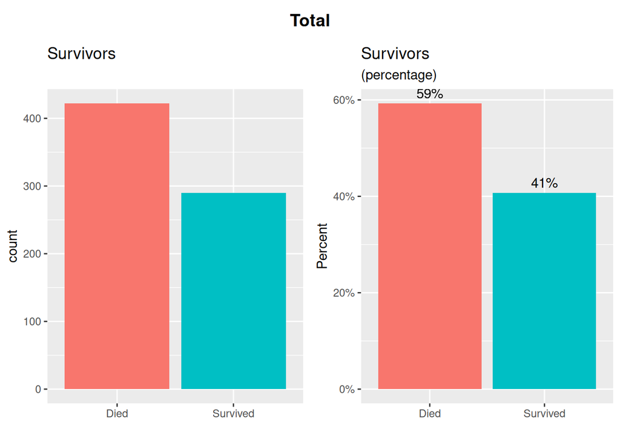

Najwięcej osób wsiadło w porcie Southampton i to z tego miasta zginęło najwięcej osób. Jedynym portem, z którego uratowało się więcej osób niż zginęło był Cherbourg.

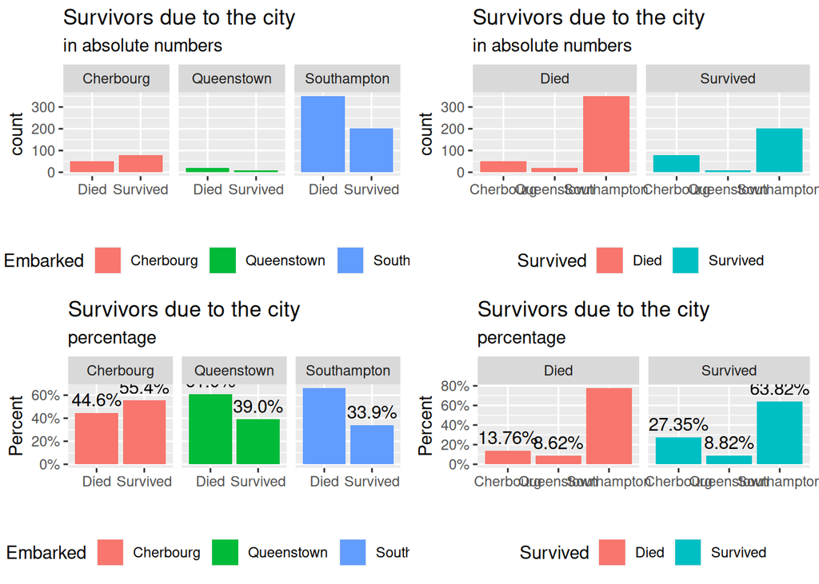

Port Cherbourg na tle innych miast wyróżniał się najlepszą sprzedażą biletów klasy pierwszej na tle inncyh miast.

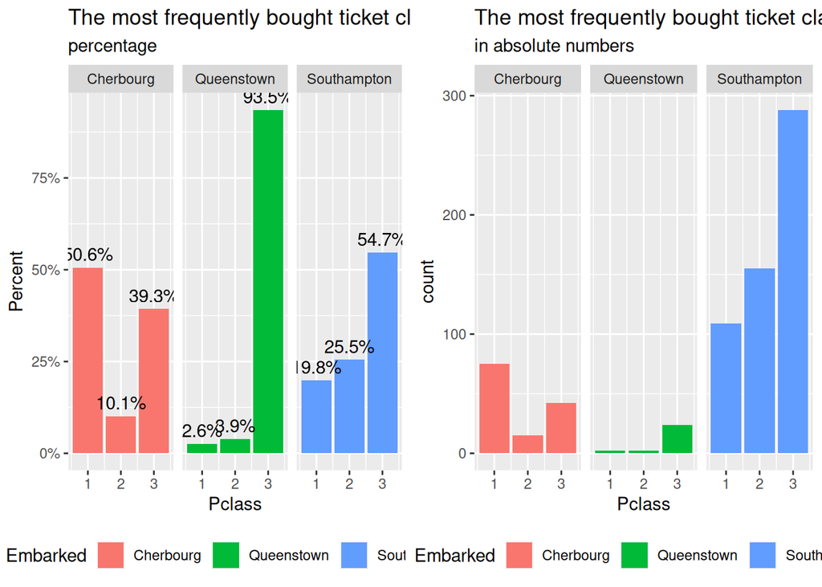

Najlepsze miejsca na statku zostały wykupione przez mieszkańców Southampton i Cherbourga, odpowiednio w 60 i 40 procentach, najgorsze z kolei w ponad 70% przez mieszkańców Southampton, spowodowane to było faktem, że większość pasażerów statku stanowili mieszkańcy Southampton, którzy byłi najbardziej zróżnicowaną grupą pod wzgędem zamożności, gdyż klasa biletu była bezpośrednio powiązana z jego ceną. Dane wskazują również, że zakup najdrożej klasy biletu był najbardziej opłacalny, gdyż uratowała się największa liczba pasażerów posiadająca tą klasę biletu - ponad 60 procent, podczas gdy los pasażerów posiadających najtańsze bilety był przesądzony - ich sznasa na przetrwanie wynosiła tylko niecałe 25 procent ponieważ taka ilość posiadaczy tych biletów zdołało się uratować, co jeszcze dobitniej obrazuje fakt, że grupa osób, które nie zdołały się uratować w aż ponad 67 procentach składa się z pasażerów posiadających najtańszą klasę biletu.

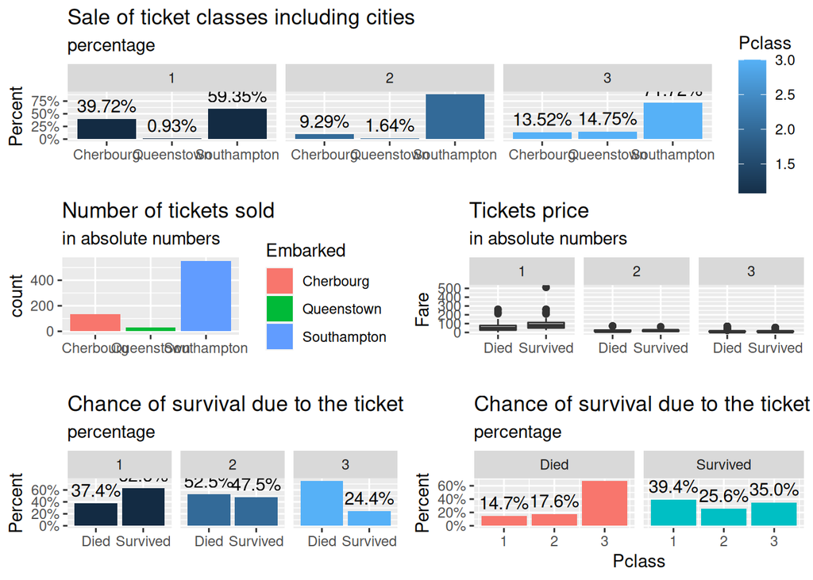

Dane wskazują na to, że większość uratowanych stanowiły kobiety, odwrotna sytuacja miała miejsce w przypadku mężczyzn. Kobiety również zachowały większą szansę na przetrwanie ponieważ około 75 procent kobiet zostało uratowanych, podczas gdy dla mężczyzn ten wskaźnik wyniósł niecałe 20 procent.

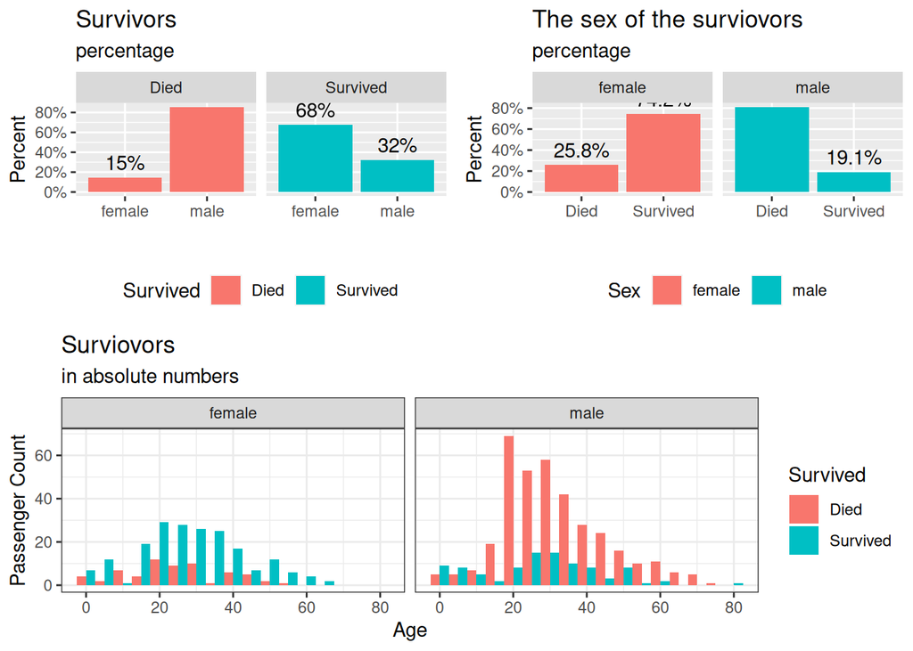

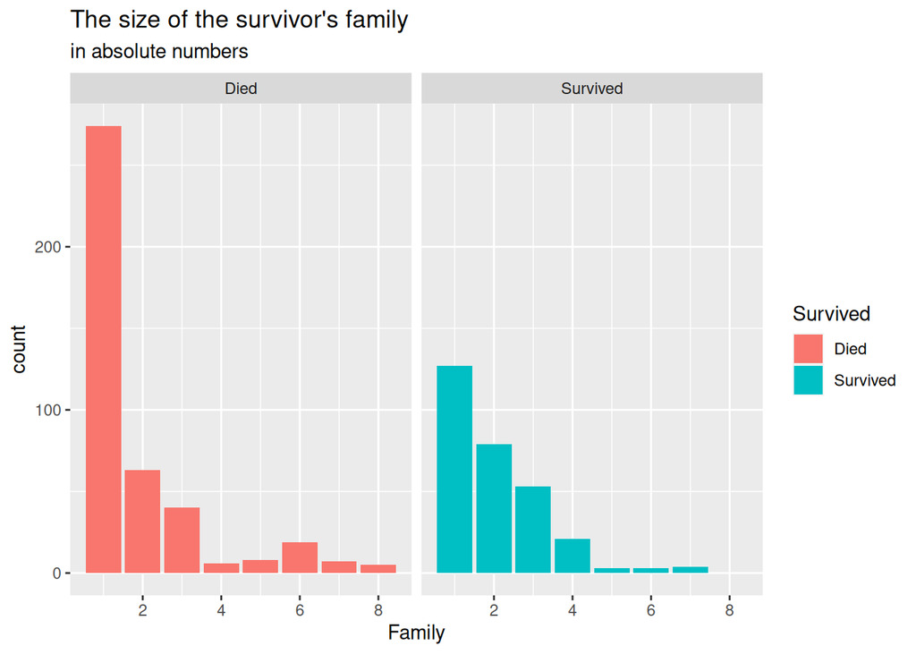

# Wnioski

Największą szansę na przetrwanie miały osoby pochodzące z Cherbourg, które kupiły bilety pierwszej klasy i będące kobietami niezależnie od tego czy podróżowały z rodziną czy bez ich szansa na przetwanie wynosiła 97 procent.

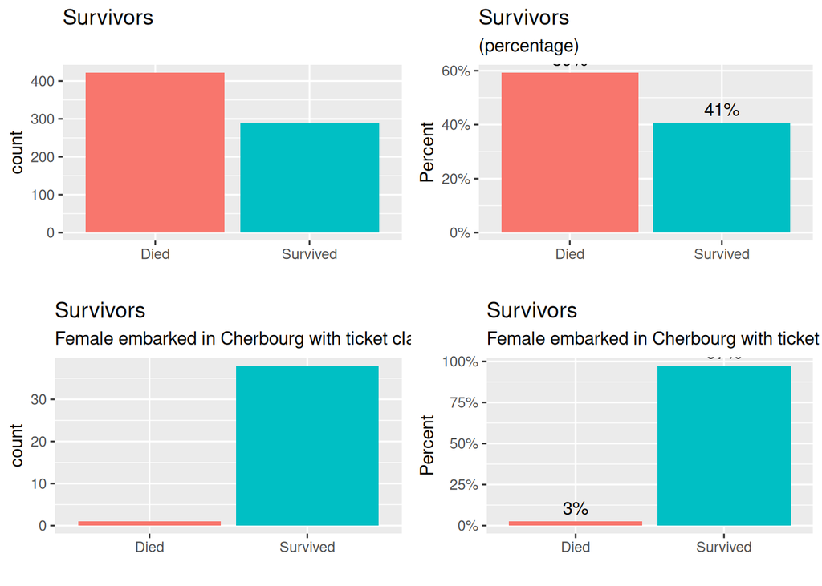